# Project: TMDB Movie Dataset analysis

- Introduction
- Data Wrangling
- Exploratory Data Analysis
- Conclusions

## Introduction

In this project, I am analyzing the TMDB movie dataset which is stored in the "tmdb-movies.csv" file. I am interested in studying the data and understanding the trends. Specifically, I am trying to answer the following questions by processing the data accordingly:

1. How has the number of movies made per year changed over the years? Has the number increased or decreased or remained about the same?
2. What is the distribution of the movies made so far in terms of the genres? Which of the genres have the highest number of movies made?
3. What is the relation between runtime of the movies and popularity? Is there a range of runtimes that the audience prefer?
4. Who are the directors with the most number of popular movies? (Note: The criteria has to be decided first for considering a movie "popular". In other words, what is the minimum value of popularity over which movies are considered popular)

```python
# Importing the required packages
import pandas as pd
import numpy as np
import matplotlib.pyplot as plt
%matplotlib inline
import seaborn as sns
```

## Data Wrangling

### General Properties

```python
# Reading in the data from the file
df = pd.read_csv('tmdb-movies.csv')
# check the dimensions of the dataframe
df.shape
```

```
(10866, 21)
```

There seem to be 10866 rows and 21 columns in the dataset. Let's explore the data a bit more

```python
df.info()
df.describe()
```

```
<class 'pandas.core.frame.DataFrame'>
RangeIndex: 10866 entries, 0 to 10865
Data columns (total 21 columns):
 #   Column                Non-Null Count  Dtype
---  ------                --------------  -----
 0   id                    10866 non-null  int64
 1   imdb_id               10856 non-null  object
 2   popularity            10866 non-null  float64
 3   budget                10866 non-null  int64
 4   revenue               10866 non-null  int64
 5   original_title        10866 non-null  object
 6   cast                  10790 non-null  object
 7   homepage              2936 non-null   object
 8   director              10822 non-null  object
 9   tagline               8042 non-null   object
 10  keywords              9373 non-null   object
 11  overview              10862 non-null  object
 12  runtime               10866 non-null  int64
 13  genres                10843 non-null  object
 14  production_companies  9836 non-null   object
 15  release_date          10866 non-null  object
 16  vote_count            10866 non-null  int64
 17  vote_average          10866 non-null  float64
 18  release_year          10866 non-null  int64
 19  budget_adj            10866 non-null  float64
 20  revenue_adj           10866 non-null  float64
dtypes: float64(4), int64(6), object(11)
memory usage: 1.7+ MB
```

|  | id | popularity | budget | revenue | runtime | vote_count | vote_average | release_year | budget_adj | revenue_adj |
| --- | --- | --- | --- | --- | --- | --- | --- | --- | --- | --- |
| count | 10866.000000 | 10866.000000 | 1.086600e+04 | 1.086600e+04 | 10866.000000 | 10866.000000 | 10866.000000 | 10866.000000 | 1.086600e+04 | 1.086600e+04 |
| mean | 66064.177434 | 0.646441 | 1.462570e+07 | 3.982332e+07 | 102.070863 | 217.389748 | 5.974922 | 2001.322658 | 1.755104e+07 | 5.136436e+07 |
| std | 92130.136561 | 1.000185 | 3.091321e+07 | 1.170035e+08 | 31.381405 | 575.619058 | 0.935142 | 12.812941 | 3.430616e+07 | 1.446325e+08 |
| min | 5.000000 | 0.000065 | 0.000000e+00 | 0.000000e+00 | 0.000000 | 10.000000 | 1.500000 | 1960.000000 | 0.000000e+00 | 0.000000e+00 |
| 25% | 10596.250000 | 0.207583 | 0.000000e+00 | 0.000000e+00 | 90.000000 | 17.000000 | 5.400000 | 1995.000000 | 0.000000e+00 | 0.000000e+00 |
| 50% | 20669.000000 | 0.383856 | 0.000000e+00 | 0.000000e+00 | 99.000000 | 38.000000 | 6.000000 | 2006.000000 | 0.000000e+00 | 0.000000e+00 |
| 75% | 75610.000000 | 0.713817 | 1.500000e+07 | 2.400000e+07 | 111.000000 | 145.750000 | 6.600000 | 2011.000000 | 2.085325e+07 | 3.369710e+07 |
| max | 417859.000000 | 32.985763 | 4.250000e+08 | 2.781506e+09 | 900.000000 | 9767.000000 | 9.200000 | 2015.000000 | 4.250000e+08 | 2.827124e+09 |

From the df.info() output, it looks like there are some null values in the columns - imdb_id, cast, homepage, director, tagline, keywords, overview, genres and production_companies. These are all strings therefore substituting by mean values etc. wouldn't work.  
Additionally, from the df.describe() output, it looks like the minimum value for the columns - budget, revenue, runtime, budget_adj and revenue_adj is zero which means there are rows with the value 0 for these columns. The rows with value zero for these columns don't make sense for example, a movie with runtime 0 or budget 0 isn't possible.

```python
df.head()
```

|  | id | imdb_id | popularity | budget | revenue | original_title | cast | homepage | director | tagline | ... | overview | runtime | genres | production_companies | release_date | vote_count | vote_average | release_year | budget_adj | revenue_adj |
| --- | --- | --- | --- | --- | --- | --- | --- | --- | --- | --- | --- | --- | --- | --- | --- | --- | --- | --- | --- | --- | --- |
| 0 | 135397 | tt0369610 | 32.985763 | 150000000 | 1513528810 | Jurassic World | Chris Pratt\|Bryce Dallas Howard\|Irrfan Khan\|Vi... | http://www.jurassicworld.com/ | Colin Trevorrow | The park is open. | ... | Twenty-two years after the events of Jurassic ... | 124 | Action\|Adventure\|Science Fiction\|Thriller | Universal Studios\|Amblin Entertainment\|Legenda... | 6/9/15 | 5562 | 6.5 | 2015 | 1.379999e+08 | 1.392446e+09 |
| 1 | 76341 | tt1392190 | 28.419936 | 150000000 | 378436354 | Mad Max: Fury Road | Tom Hardy\|Charlize Theron\|Hugh Keays-Byrne\|Nic... | http://www.madmaxmovie.com/ | George Miller | What a Lovely Day. | ... | An apocalyptic story set in the furthest reach... | 120 | Action\|Adventure\|Science Fiction\|Thriller | Village Roadshow Pictures\|Kennedy Miller Produ... | 5/13/15 | 6185 | 7.1 | 2015 | 1.379999e+08 | 3.481613e+08 |
| 2 | 262500 | tt2908446 | 13.112507 | 110000000 | 295238201 | Insurgent | Shailene Woodley\|Theo James\|Kate Winslet\|Ansel... | http://www.thedivergentseries.movie/#insurgent | Robert Schwentke | One Choice Can Destroy You | ... | Beatrice Prior must confront her inner demons ... | 119 | Adventure\|Science Fiction\|Thriller | Summit Entertainment\|Mandeville Films\|Red Wago... | 3/18/15 | 2480 | 6.3 | 2015 | 1.012000e+08 | 2.716190e+08 |
| 3 | 140607 | tt2488496 | 11.173104 | 200000000 | 2068178225 | Star Wars: The Force Awakens | Harrison Ford\|Mark Hamill\|Carrie Fisher\|Adam D... | http://www.starwars.com/films/star-wars-episod... | J.J. Abrams | Every generation has a story. | ... | Thirty years after defeating the Galactic Empi... | 136 | Action\|Adventure\|Science Fiction\|Fantasy | Lucasfilm\|Truenorth Productions\|Bad Robot | 12/15/15 | 5292 | 7.5 | 2015 | 1.839999e+08 | 1.902723e+09 |
| 4 | 168259 | tt2820852 | 9.335014 | 190000000 | 1506249360 | Furious 7 | Vin Diesel\|Paul Walker\|Jason Statham\|Michelle ... | http://www.furious7.com/ | James Wan | Vengeance Hits Home | ... | Deckard Shaw seeks revenge against Dominic Tor... | 137 | Action\|Crime\|Thriller | Universal Pictures\|Original Film\|Media Rights ... | 4/1/15 | 2947 | 7.3 | 2015 | 1.747999e+08 | 1.385749e+09 |

5 rows × 21 columns

Checking for duplicate values:

```python
df[df.duplicated()]
```

|  | id | imdb_id | popularity | budget | revenue | original_title | cast | homepage | director | tagline | ... | overview | runtime | genres | production_companies | release_date | vote_count | vote_average | release_year | budget_adj | revenue_adj |
| --- | --- | --- | --- | --- | --- | --- | --- | --- | --- | --- | --- | --- | --- | --- | --- | --- | --- | --- | --- | --- | --- |
| 2090 | 42194 | tt0411951 | 0.59643 | 30000000 | 967000 | TEKKEN | Jon Foo\|Kelly Overton\|Cary-Hiroyuki Tagawa\|Ian... | NaN | Dwight H. Little | Survival is no game | ... | In the year of 2039, after World Wars destroy ... | 92 | Crime\|Drama\|Action\|Thriller\|Science Fiction | Namco\|Light Song Films | 3/20/10 | 110 | 5.0 | 2010 | 30000000.0 | 967000.0 |

1 rows × 21 columns

There seems to be one row which is a duplicate, this can be dropped.

### Data Cleaning steps

The below steps can be followed to clean the data and transform it into a usable format.

#### Dropping the duplicated row

```python
#to drop the duplicate row inplace
df.drop_duplicates(inplace=True)
#check again to make sure there are no more duplicate rows
df[df.duplicated()]
```

|  | id | imdb_id | popularity | budget | revenue | original_title | cast | homepage | director | tagline | ... | overview | runtime | genres | production_companies | release_date | vote_count | vote_average | release_year | budget_adj | revenue_adj |
| --- | --- | --- | --- | --- | --- | --- | --- | --- | --- | --- | --- | --- | --- | --- | --- | --- | --- | --- | --- | --- | --- |

0 rows × 21 columns

```python
df.drop(['imdb_id','budget','revenue','cast','homepage','tagline','keywords','overview','release_date','production_companies','vote_count','vote_average','budget_adj','revenue_adj'],axis=1,inplace=True)
df.info()
```

```
<class 'pandas.core.frame.DataFrame'>
Int64Index: 10865 entries, 0 to 10865
Data columns (total 7 columns):
 #   Column          Non-Null Count  Dtype
---  ------          --------------  -----
 0   id              10865 non-null  int64
 1   popularity      10865 non-null  float64
 2   original_title  10865 non-null  object
 3   director        10821 non-null  object
 4   runtime         10865 non-null  int64
 5   genres          10842 non-null  object
 6   release_year    10865 non-null  int64
dtypes: float64(1), int64(3), object(3)
memory usage: 679.1+ KB
```

#### Check to see if there are any null values

```python
df[df.isnull().any(axis=1)]
```

|  | id | popularity | original_title | director | runtime | genres | release_year |
| --- | --- | --- | --- | --- | --- | --- | --- |
| 424 | 363869 | 0.244648 | Belli di papÃ | Guido Chiesa | 100 | NaN | 2015 |
| 532 | 320996 | 0.126594 | Iliza Shlesinger: Freezing Hot | NaN | 71 | Comedy | 2015 |
| 548 | 355131 | 0.108072 | Sense8: Creating the World | NaN | 25 | Documentary\|Science Fiction | 2015 |
| 556 | 321160 | 0.100910 | With This Ring | NaN | 105 | Comedy\|Romance | 2015 |
| 620 | 361043 | 0.129696 | All Hallows' Eve 2 | Antonio Padovan\|Bryan Norton\|Marc Roussel\|Ryan... | 90 | NaN | 2015 |
| ... | ... | ... | ... | ... | ... | ... | ... |
| 9593 | 46188 | 0.001662 | Peter Pan | NaN | 52 | Action\|Adventure\|Animation\|Family\|Fantasy | 1988 |
| 9799 | 48847 | 0.175008 | The Amputee | David Lynch | 5 | NaN | 1974 |
| 10386 | 225804 | 0.118854 | The Making of 'The Nightmare Before Christmas' | NaN | 25 | Documentary | 1993 |
| 10426 | 34038 | 0.114034 | Magical Mystery Tour | NaN | 55 | Music | 1967 |
| 10659 | 4255 | 0.344172 | The Party at Kitty and Stud's | Morton Lewis | 71 | NaN | 1970 |

65 rows × 7 columns

#### Dropping the rows containing null values:

```python
df.dropna(inplace=True)
df.shape
```

```
(10800, 7)
```

#### Checking now to see how many rows have runtime equals 0

```python
df[df['runtime']==0].shape
```

```
(28, 7)
```

Since this is a small number of rows, dropping them:

```python
df.drop(df[df['runtime']==0].index,inplace=True)
df.shape
```

```
(10772, 7)
```

```python
df.head()
```

|  | id | popularity | original_title | director | runtime | genres | release_year |
| --- | --- | --- | --- | --- | --- | --- | --- |
| 0 | 135397 | 32.985763 | Jurassic World | Colin Trevorrow | 124 | Action\|Adventure\|Science Fiction\|Thriller | 2015 |
| 1 | 76341 | 28.419936 | Mad Max: Fury Road | George Miller | 120 | Action\|Adventure\|Science Fiction\|Thriller | 2015 |
| 2 | 262500 | 13.112507 | Insurgent | Robert Schwentke | 119 | Adventure\|Science Fiction\|Thriller | 2015 |
| 3 | 140607 | 11.173104 | Star Wars: The Force Awakens | J.J. Abrams | 136 | Action\|Adventure\|Science Fiction\|Fantasy | 2015 |
| 4 | 168259 | 9.335014 | Furious 7 | James Wan | 137 | Action\|Crime\|Thriller | 2015 |

The column 'genres' seems to have multiple values concatenated together using the character " | ". Because I am using this column in my analysis, I need to unpack the column into multiple columns.  
For that, I need a list of genres:

```python
#get the unique set of genres
GL = set([y for x in df.genres.tolist() for y in x.split('|')])
print(len(GL))
print(GL)
```

```
20
{'Science Fiction', 'Foreign', 'Mystery', 'Thriller', 'Western', 'Crime', 'Fantasy', 'Drama', 'Animation', 'Horror', 'TV Movie', 'Family', 'Documentary', 'Action', 'Music', 'Adventure', 'History', 'Comedy', 'War', 'Romance'}
```

The values in 'genres' are concatenated with the pipe | character. So, I have added additional columns for each of the genre and set the boolean values accordingly. In other words, if a movie is a science fiction but also with action, the 'Science Fiction' and 'Action' columns would have a value of 1 and the other genre columns would have a value of 0.

```python
df1=df.genres.str.get_dummies()
df_final=pd.concat([df,df1],axis=1)
print(df_final.shape)
df_final.head()
```

```
(10772, 27)
```

|  | id | popularity | original_title | director | runtime | genres | release_year | Action | Adventure | Animation | ... | History | Horror | Music | Mystery | Romance | Science Fiction | TV Movie | Thriller | War | Western |
| --- | --- | --- | --- | --- | --- | --- | --- | --- | --- | --- | --- | --- | --- | --- | --- | --- | --- | --- | --- | --- | --- |
| 0 | 135397 | 32.985763 | Jurassic World | Colin Trevorrow | 124 | Action\|Adventure\|Science Fiction\|Thriller | 2015 | 1 | 1 | 0 | ... | 0 | 0 | 0 | 0 | 0 | 1 | 0 | 1 | 0 | 0 |
| 1 | 76341 | 28.419936 | Mad Max: Fury Road | George Miller | 120 | Action\|Adventure\|Science Fiction\|Thriller | 2015 | 1 | 1 | 0 | ... | 0 | 0 | 0 | 0 | 0 | 1 | 0 | 1 | 0 | 0 |
| 2 | 262500 | 13.112507 | Insurgent | Robert Schwentke | 119 | Adventure\|Science Fiction\|Thriller | 2015 | 0 | 1 | 0 | ... | 0 | 0 | 0 | 0 | 0 | 1 | 0 | 1 | 0 | 0 |
| 3 | 140607 | 11.173104 | Star Wars: The Force Awakens | J.J. Abrams | 136 | Action\|Adventure\|Science Fiction\|Fantasy | 2015 | 1 | 1 | 0 | ... | 0 | 0 | 0 | 0 | 0 | 1 | 0 | 0 | 0 | 0 |
| 4 | 168259 | 9.335014 | Furious 7 | James Wan | 137 | Action\|Crime\|Thriller | 2015 | 1 | 0 | 0 | ... | 0 | 0 | 0 | 0 | 0 | 0 | 0 | 1 | 0 | 0 |

5 rows × 27 columns

## Exploratory Data Analysis

### Research Question 1 - Number of movies made per year

I am taking just the columns 'id' and 'release_year' from the dataframe and grouping by 'release_year'. Then I can count the number of movies per year using count() as follows:

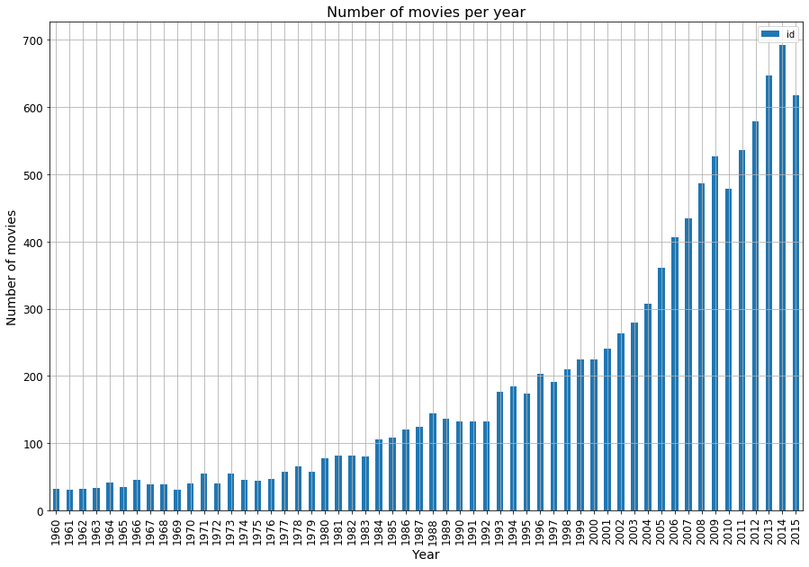

```python
#pulling the id and release_year columns and grouping by release_year and counting the number of movies per year
df_movies = df_final[['id','release_year']].groupby('release_year').count().plot(kind='bar', figsize=(15,10),fontsize=12,grid=True);
#setup the title of the figure
plt.title("Number of movies per year",fontsize = 16)
#setup the x-label and y-label of the plot.
plt.xlabel('Year',fontsize = 14)
plt.ylabel('Number of movies',fontsize = 14)
```

### Research Question 2 - Distribution of movies into different genres

GL contains the list of genres available. I am filtering just the columns containing genre information i.e. the individual genre columns. The sum() function would then give a count of movies in each genre since the individual genre column contains boolean values so the sum is essentially a count of "true" values.

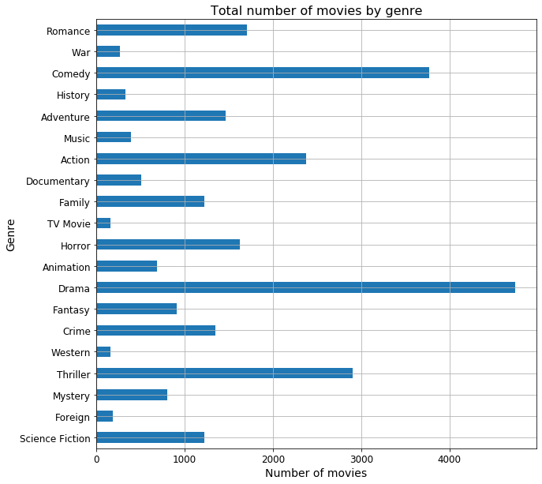

```python
#getting a number of movies in each genre by counting the number of True values
GL = list(GL)
df_final[GL].sum(axis=0).plot(kind='barh',figsize=(10,10),fontsize=12,grid=True)
#setup the title of the figure
plt.title("Total number of movies by genre",fontsize = 16)
#setup the x-label and y-label of the plot.
plt.xlabel('Number of movies',fontsize = 14)
plt.ylabel('Genre',fontsize = 14)
```

### Research Question 3 - Runtime vs popularity

The data is being grouped by runtime and the popularity column is being fetched. The mean popularity is being calculated for each group of runtime values.

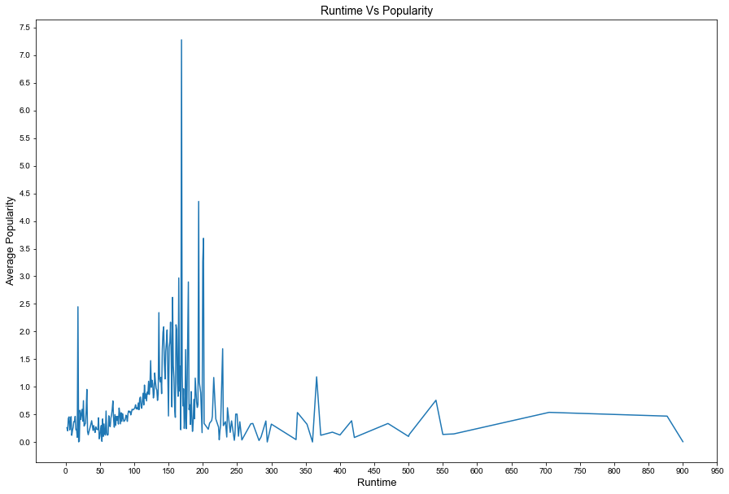

```python
#print(df_final.runtime.nunique())
df_runtime_popularity = df_final.groupby('runtime')['popularity'].mean().plot(figsize = (15,10),xticks=np.arange(0,1000,50),yticks=np.arange(0,8,0.5))
#setup the title of the figure
plt.title("Runtime Vs Popularity",fontsize = 14)
#setup the x-label and y-label of the plot.
plt.xlabel('Runtime',fontsize = 13)
plt.ylabel('Average Popularity',fontsize = 13)
#setup the figure size.
sns.set(rc={'figure.figsize':(10,5)})
sns.set_style("darkgrid")
```

### Research Question 4 - Top 5 Directors with most number of popular movies

I have selected the 50% percentile value of popularity which is 0.386176. Therefore, any movie with popularity greater than or equal to this value is assumed to be popular.

```python
#decide what is the popularity threshold to be set
df.describe()
```

|  | id | popularity | runtime | release_year |
| --- | --- | --- | --- | --- |
| count | 10772.000000 | 10772.000000 | 10772.000000 | 10772.000000 |
| mean | 65282.304029 | 0.650643 | 102.455347 | 2001.265503 |
| std | 91452.460328 | 1.003319 | 30.379156 | 12.825332 |
| min | 5.000000 | 0.000188 | 2.000000 | 1960.000000 |
| 25% | 10558.500000 | 0.209987 | 90.000000 | 1995.000000 |
| 50% | 20408.500000 | 0.386176 | 99.000000 | 2006.000000 |
| 75% | 74462.000000 | 0.718889 | 112.000000 | 2011.000000 |
| max | 417859.000000 | 32.985763 | 900.000000 | 2015.000000 |

```python
#check which director has more movies in the popular movies
df_popular_director = df[['id','director']][df['popularity'] >= 0.386176].groupby('director')['id']
df_popular_director.count().nlargest(5)
```

```
director
Woody Allen         38
Clint Eastwood      27
Steven Spielberg    27
Martin Scorsese     19
Ridley Scott        19
Name: id, dtype: int64
```